# Assignment 4

In this assignment, you'll combine the assignment 3 data set with nutrition data from the [USDA Food Composition Databases](https://ndb.nal.usda.gov/ndb/search/list). The CSV file `fresh.csv` contains the fresh fruits and vegetables data you extracted in assignment 3.

The USDA Food Composition Databases have a [documented](https://ndb.nal.usda.gov/ndb/doc/index) web API that returns data in JSON format . You need a key in order to use the API. Only 1000 requests are allowed per hour, so it would be a good idea to use [caching](https://pypi.python.org/pypi/requests-cache).

[Sign up for an API key here](https://api.data.gov/signup/). The key will work with any Data.gov API. You may need the key again later in the quarter, so make sure you save it.

These modules may be useful:

- [requests](http://docs.python-requests.org/en/master/user/quickstart/)
- [requests_cache](https://pypi.python.org/pypi/requests-cache)
- [urlparse](https://docs.python.org/2/library/urlparse.html)
- [pandas](http://pandas.pydata.org/pandas-docs/stable/)

**Exercise 1.1.** Read the [search request documentation](https://ndb.nal.usda.gov/ndb/doc/apilist/API-SEARCH.md), then write a function called `ndb_search()` that makes a search request. The function should accept the search term as an argument. The function should return the search result items as a list (for 0 items, return an empty list).

Note that the search url is: `https://api.nal.usda.gov/ndb/search`

As an example, a search for `"quail eggs"` should return this list:

```
[{u'ds': u'BL',
  u'group': u'Branded Food Products Database',
  u'name': u'CHAOKOH, QUAIL EGG IN BRINE, UPC: 044738074186',
  u'ndbno': u'45094707',
  u'offset': 0},
 {u'ds': u'BL',
  u'group': u'Branded Food Products Database',
  u'name': u'L&W, QUAIL EGGS, UPC: 024072000256',
  u'ndbno': u'45094890',
  u'offset': 1},
 {u'ds': u'BL',
  u'group': u'Branded Food Products Database',
  u'name': u'BUDDHA, QUAIL EGGS IN BRINE, UPC: 761934535098',
  u'ndbno': u'45099560',
  u'offset': 2},
 {u'ds': u'BL',
  u'group': u'Branded Food Products Database',
  u'name': u'GRAN SABANA, QUAIL EGGS, UPC: 819140010103',
  u'ndbno': u'45169279',
  u'offset': 3},
 {u'ds': u'BL',
  u'group': u'Branded Food Products Database',
  u'name': u"D'ARTAGNAN, QUAIL EGGS, UPC: 736622102630",
  u'ndbno': u'45178254',
  u'offset': 4},
 {u'ds': u'SR',
  u'group': u'Dairy and Egg Products',
  u'name': u'Egg, quail, whole, fresh, raw',
  u'ndbno': u'01140',
  u'offset': 5}]
```

As usual, make sure you document and test your function.

```python
import requests, requests_cache
import matplotlib.cm as cmx
import matplotlib.colors as colors
import pandas as pd
import numpy as np
import matplotlib
import matplotlib.pyplot as plt
matplotlib.style.use("ggplot")
requests_cache.install_cache("cache")
```

```python
def ndb_search(searchTerm, key):
    """
    Input: The search term and API key
    Output: The search result items as a list (for 0 items, return an empty list).
    """
    base =  "https://api.nal.usda.gov/ndb/search/"
    base = base + "?" + "format=json"
    base = base + "&q=" + searchTerm
    base = base + "&api_key=" + key
    response = requests.get(base)
    response = response.json()
    return response


# key = "PutYourKeyHere"
ndb_search("quail eggs", key)
```

```
{u'list': {u'ds': u'any',
  u'end': 6,
  u'group': u'',
  u'item': [{u'ds': u'BL',
    u'group': u'Branded Food Products Database',
    u'name': u'CHAOKOH, QUAIL EGG IN BRINE, UPC: 044738074186',
    u'ndbno': u'45094707',
    u'offset': 0},
   {u'ds': u'BL',
    u'group': u'Branded Food Products Database',
    u'name': u'L&W, QUAIL EGGS, UPC: 024072000256',
    u'ndbno': u'45094890',
    u'offset': 1},
   {u'ds': u'BL',
    u'group': u'Branded Food Products Database',
    u'name': u'BUDDHA, QUAIL EGGS IN BRINE, UPC: 761934535098',
    u'ndbno': u'45099560',
    u'offset': 2},
   {u'ds': u'BL',
    u'group': u'Branded Food Products Database',
    u'name': u'GRAN SABANA, QUAIL EGGS, UPC: 819140010103',
    u'ndbno': u'45169279',
    u'offset': 3},
   {u'ds': u'BL',
    u'group': u'Branded Food Products Database',
    u'name': u"D'ARTAGNAN, QUAIL EGGS, UPC: 736622102630",
    u'ndbno': u'45178254',
    u'offset': 4},
   {u'ds': u'SR',
    u'group': u'Dairy and Egg Products',
    u'name': u'Egg, quail, whole, fresh, raw',
    u'ndbno': u'01140',
    u'offset': 5}],
  u'q': u'quail eggs',
  u'sort': u'r',
  u'sr': u'28',
  u'start': 0,
  u'total': 6}}
```

**Exercise 1.2.** Use your search function to get NDB numbers for the foods in the `fresh.csv` file. It's okay if you don't get an NDB number for every food, but try to come up with a strategy that gets most of them. Discuss your strategy in a short paragraph.

Hints:

- The foods are all raw and unbranded.
- You can test search terms with the [online search page](https://ndb.nal.usda.gov/ndb/search/list).
- You can convert the output of `ndb_search()` to a data frame with `pd.DataFrame()`.
- The string methods for [Python](https://docs.python.org/2/library/stdtypes.html#string-methods) and [Pandas](http://pandas.pydata.org/pandas-docs/stable/text.html#method-summary) are useful here. It's okay if you use *simple* regular expressions in the Pandas methods, although this exercise can be solved without them.
- You can merge data frames that have a column in common with `pd.merge()`.

```python
def getNDBNums(df, searchCol, key):
    """
    Input: df = a starting data frame.
           searchCol = the name of the column in the df with what to search for.
           key = the API key.
    Output: the same df but with a new column ndb.
    """
    types = df["type"]
    cols = ("food", "ndbNum")
    foodNDB = pd.DataFrame(columns = cols)
    for fruitVeg in fresh[searchCol]: #49
        # Get search results:
        resultJSON = ndb_search(fruitVeg, key)

        # Elimate search results with words that we don't want:
        dfOptions = pd.DataFrame(resultJSON["list"]["item"])
        badWords = ["juice", "sparkling", "with", "and ", "&", "sauce", "soda",
                    "syrup", "bread", "drink", " seed", " gum", " sour", "flavor",
                   "yogurt", "beverage", "punch", "cooler", "tea", "snack",
                   "pureed", "kool-aid", "fruit roll"]
        for word in badWords:
            dfOptions = dfOptions[dfOptions["name"].str.lower().str.find(word) == -1]

        # If it contains the word raw, then only keep those:
        if any(dfOptions["name"].str.lower().str.find("raw")) != -1:
            dfOptions = dfOptions[dfOptions["name"].str.lower().str.find("raw") != -1]

        # If any left are in the Fruits and Fruit Juices group, pick those:
        if any(dfOptions["group"] == "Fruits and Fruit Juices"):
            dfOptions = dfOptions[dfOptions["group"] == "Fruits and Fruit Juices"]
        # Same for veggies:
        elif any(dfOptions["group"] == "Vegetables and Vegetable Products"):
            dfOptions = dfOptions[dfOptions["group"] == "Vegetables and Vegetable Products"]

        # If it has the food name then keep those (sweet corn has diff order so need if):
        if any(dfOptions["name"].str.lower().str.find(fruitVeg) != -1) :
            dfOptions = dfOptions[dfOptions["name"].str.lower().str.find(fruitVeg) != -1]

        # Now grab the first one -> most relevant search result once the changes
        # above are made. Seems to be the best one to pick for most cases.
        if (dfOptions.shape[0] > 0):
            ndbNum = dfOptions.iloc[0]["ndbno"]
        else:
            ndbNum = np.nan # problem: equal to previous

        # Now add to dataframe with just food and nbdNum
        newFood = pd.DataFrame([[fruitVeg, ndbNum]], columns = cols)
        foodNDB = foodNDB.append(newFood)

    # Now merege with original data frame
    dfMerge = pd.merge(df, foodNDB)

    return dfMerge

fresh = pd.read_csv("fresh.csv")
fresh["food"] = fresh["food"].str.replace("_", " ")
fresh = getNDBNums(fresh, "food", key)
fresh = fresh.drop_duplicates()
fresh.head()
```

|  | form | price_per_lb | yield | lb_per_cup | price_per_cup | food | type | ndbNum |
| --- | --- | --- | --- | --- | --- | --- | --- | --- |
| 0 | Fresh1 | 0.333412 | 0.52 | 0.330693 | 0.212033 | watermelon | fruit | 09326 |
| 1 | Fresh1 | 0.535874 | 0.51 | 0.374786 | 0.393800 | cantaloupe | fruit | 09181 |
| 2 | Fresh1 | 1.377962 | 0.74 | 0.407855 | 0.759471 | tangerines | fruit | 09218 |
| 3 | Fresh1 | 2.358808 | 0.94 | 0.319670 | 0.802171 | strawberries | fruit | 09316 |
| 4 | Fresh1 | 1.827416 | 0.94 | 0.363763 | 0.707176 | plums | fruit | 09279 |

My strategy for getting as many NDB numbers as possible started by eliminating search results containing "bad words." I consider these bad words to be "juice", "sparkling", "with", "and ", "&", "sauce", "soda", "syrup", "bread", "drink", " seed", " gum", " sour", "yogurt", "beverage", "punch", "cooler", "tea", "snack", "pureed", "kool-aid", "fruit roll" and "flavor". These words clearly indicated that the search result is not fruit or vegetable we are looking for. I added spaces before some of these words to catch cases like mandarin that contain "and." Now having eliminated those words, if there were any results with the word raw, then I kept those. Not all foods contained raw, so the if was necessary. In the cases where raw was found, that was always the best search result. Then I did the same kind of check for foods with a group of "Fruits and Fruit Juices" or "Vegetables and Vegetable Products." For the cases where there were search results with these group titles, those were the best options. Then I did a final narrowing down of searching for the food name and if it was found, using what was found. I could only do this in the cases where a result was found because of foods like sweet corn which appeared with commas in between in the search results. Before doing this final search, I replaced all underscores with spaces in the food names. Then I just grabbed the first result. From looking at the results that were left at this point for some of the foods, picking the first one was either the best option or any of the results left worked.

**Exercise 1.3.** Read the [food reports V2 documentation](https://ndb.nal.usda.gov/ndb/doc/apilist/API-FOOD-REPORTV2.md), then write a function called `ndb_report()` that requests a *basic* food report. The function should accept the NDB number as an argument and return the list of nutrients for the food.

Note that the report url is: `https://api.nal.usda.gov/ndb/V2/reports`

For example, for `"09279"` (raw plums) the first element of the returned list should be:

```
{u'group': u'Proximates',
 u'measures': [{u'eqv': 165.0,
   u'eunit': u'g',
   u'label': u'cup, sliced',
   u'qty': 1.0,
   u'value': u'143.93'},
  {u'eqv': 66.0,
   u'eunit': u'g',
   u'label': u'fruit (2-1/8" dia)',
   u'qty': 1.0,
   u'value': u'57.57'},
  {u'eqv': 151.0,
   u'eunit': u'g',
   u'label': u'NLEA serving',
   u'qty': 1.0,
   u'value': u'131.72'}],
 u'name': u'Water',
 u'nutrient_id': u'255',
 u'unit': u'g',
 u'value': u'87.23'}
```

Be sure to document and test your function.

```python
def ndb_report(ndbNum):
    """
    This function requests a basic food report.
    Input: The NDB number
    Output: The list of nutrients for the food
    """
    base = "https://api.nal.usda.gov/ndb/V2/reports"
    base = base + "?" + "ndbno=" + str(ndbNum)
    base = base + "&type=b" + "&format=json"
    base = base + "&api_key=" + key
    response = requests.get(base)
    response = response.json()
    response = response['foods'][0]["food"]["nutrients"]
    return response

ndb_report(fresh.ix[4, "ndbNum"])[0]
```

```
{u'group': u'Proximates',
 u'measures': [{u'eqv': 165.0,
   u'eunit': u'g',
   u'label': u'cup, sliced',
   u'qty': 1.0,
   u'value': u'143.93'},
  {u'eqv': 66.0,
   u'eunit': u'g',
   u'label': u'fruit (2-1/8" dia)',
   u'qty': 1.0,
   u'value': u'57.57'},
  {u'eqv': 151.0,
   u'eunit': u'g',
   u'label': u'NLEA serving',
   u'qty': 1.0,
   u'value': u'131.72'}],
 u'name': u'Water',
 u'nutrient_id': u'255',
 u'unit': u'g',
 u'value': u'87.23'}
```

**Exercise 1.4.** Which foods provide the best combination of price, yield, and nutrition? You can use kilocalories as a measure of "nutrition" here, but more a detailed analysis is better. Use plots to support your analysis.

I started by using the function from exercise 1.3 to add a bunch more columns to the fresh data frame to use to find a better measure of nutrition than just kilocalories. Looking through the nutrition information listed, other than engery, most of them are in grams, miligrams, or micrograms. This means that they can be converted to grams and combined to make one measure of nutrition. My idea is to categorize each one as good or bad. I am no nutritionist, so I am not sure how valid this will be as a measurement of nutrition. I am going to make the good ones positive and the bad ones negative, keeping in mind what nutrients we look for in fruits and vegetables. Since micrograms are so much smaller than grams, adding or subtracting those nutrients will make a tiny tiny difference, so I am only going to focus on the gram and miligram measurements.  
This leaves the good:

- Protien (g): positive
- Fiber (g): positive
- Calcium (mg): positive
- Iron (mg): positive
- Potasium (mg): positive
- Vitamin C (mg): positive
- Magnesium (mg): positive
- Phosphorus (mg): positive
- Zinc (mg): positive
- Thiamin (mg): positive
- Riboflavin (mg): positive
- Vitamin B-6 (mg): positive
- Vitamin E (mg): positive
- Monounsaturated fatty acids(g): positive
- Polyunsaturated fatty acids(g): positive

And the bad:

- Total lipid fat(g): negative
- Carbohydrate (g): negative
- Sugars (g): negative
- Cholesterol(mg): negative
- Sodium (mg): negative
- Saturated fatty acids (g): negative
- Trans fatty acids (g): negative

I did not use water since it is not very clear where is falls. I will also be using energy as a measure of nutrition, just separately since its units are so different. Since there are so many nutrients, making all of these variables columns in the data frame and then adding them up would be excesive considering I am just using the sum of them all. So, I will just be adding four new columns to the dataframe: energy(kcal), nutritionEst(g), nutritionEstG(g), and nutritionEstB(g). Where the last two are the "good" and "bad" nutrient sums.

```python
def nutrition(fresh):
    """
    Input: The fresh data frame.
    Output: The same data frame with four more columns: energy, nutritionEst,
    nutritionEstG, and nutritionEstB (for good and bad).
    """
    cols = ["food", "energy", "nutritionEst", "nutritionEstG", "nutritionEstB"]
    newColsDF = pd.DataFrame(columns = cols)
    good = ["Protein", "Fiber, total dietary", "Fatty acids, total monounsaturated",
            "Fatty acids, total polyunsaturated", "Calcium, Ca", "Iron, Fe",
             "Magnesium, Mg", "Phosphorus, P", "Potassium, K", "Zinc, Zn",
             "Thiamin", "Riboflavin", "Vitamin B-6",
            "Vitamin C, total ascorbic acid", "Vitamin E (alpha-tocopherol)"]
    bad = ["Total lipid (fat)", "Carbohydrate, by difference", "Sugars, total",
           "Fatty acids, total saturated", "Fatty acids, total trans",
            "Sodium, Na", "Cholesterol"]
    # Go through each ndpNum and get energy and nutritionEst
    for num, food in zip(fresh.ix[:, "ndbNum"], fresh["food"]):

        # Only want ndpNums that are not NaN:
        if np.isnan(float(num)) == False:

            # Get API info and read into data frame:
            jsonInfo = ndb_report(fresh[fresh["food"] == food]["ndbNum"].iloc[0])
            info = pd.DataFrame(jsonInfo)

            # Get energy:
            energy = float(info[info["name"] == "Energy"]["value"]) # .iloc[0])

            # Get nutrition estimate:
            nutEstG, nutEstB, nutEst = 0, 0, 0
            goodInfo = [info[info["name"] == g] for g in good]
            badInfo = [info[info["name"] == b] for b in bad]
            for gi in goodInfo + badInfo:
                # If that food has a value for that nutrition type:
                if gi["value"].shape[0] > 0 :
                    value = float(gi["value"].iloc[0])
                    # Convert to grams if necessary:
                    if gi["unit"].iloc[0] == "mg":
                        value = value / 1000
                    # If good nutrition type, then add:
                    if any([gi["name"].iloc[0] == g for g in good]):
                        nutEstG = nutEstG + value
                        nutEst = nutEst + value
                    else: # Bad then subtract:
                        nutEstB = nutEstB + value
                        nutEst = nutEst - value
                # Not found so zero grams:

            tempdf = pd.DataFrame([[food, energy, nutEst, nutEstG, nutEstB]], columns = cols)
            newColsDF = newColsDF.append(tempdf)

    return pd.merge(newColsDF, fresh)

fresh = nutrition(fresh)
fresh.head()
```

|  | food | energy | nutritionEst | nutritionEstG | nutritionEstB | form | price_per_lb | yield | lb_per_cup | price_per_cup | type | ndbNum |
| --- | --- | --- | --- | --- | --- | --- | --- | --- | --- | --- | --- | --- |
| 0 | watermelon | 30.0 | -12.671411 | 1.245589 | 13.917 | Fresh1 | 0.333412 | 0.52 | 0.330693 | 0.212033 | fruit | 09326 |
| 1 | cantaloupe | 34.0 | -14.112728 | 2.164272 | 16.277 | Fresh1 | 0.535874 | 0.51 | 0.374786 | 0.393800 | fruit | 09181 |
| 2 | tangerines | 53.0 | -21.273708 | 2.997292 | 24.271 | Fresh1 | 1.377962 | 0.74 | 0.407855 | 0.759471 | fruit | 09218 |
| 3 | strawberries | 32.0 | -9.752267 | 3.133733 | 12.886 | Fresh1 | 2.358808 | 0.94 | 0.319670 | 0.802171 | fruit | 09316 |
| 4 | plums | 46.0 | -19.162887 | 2.474113 | 21.637 | Fresh1 | 1.827416 | 0.94 | 0.363763 | 0.707176 | fruit | 09279 |

So after getting the nutrition estimate (nutritionEst) above and comparing the numbers to just the estimate for "good" nutrition (nutritionEstG), the "good" estimate makes more sense. Subtracting the "bad" nutrition for the estimate had good intentions, but we end up with cucumber as the most nutritious. The "good" estimate makes more sense, for example avocado, brussel sprouts, and raspberries are near the top and cucumbers are near the bottom. To find which foods provide the best combination of price, yield, and nutrition I made two plots.

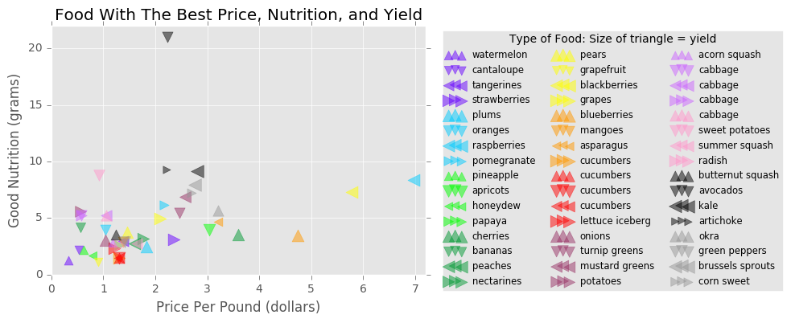

```python
from matplotlib.font_manager import FontProperties
fontP = FontProperties()
fontP.set_size('small')

div4 = np.ceil(int(fresh.shape[0]) / 4.0)
div4List = np.repeat(range(0, int(div4) + 1) , 5)
norm = matplotlib.colors.Normalize()
myColors = [(102, 0, 255), (0, 204, 255), (0, 255, 0), (0, 153, 51),
          (255, 255, 0), (255, 153, 0), (255, 0.0, 0), (153, 51, 102),
          (204, 102, 255), (255, 153, 204), (0,0,0), (152,152,152)]
myColors = norm(myColors)

myColors = np.repeat(myColors, 4, axis = 0)
cmap = get_cmap(div4)
marks = ["^", "v", "<", ">"] * (12)

for i in xrange(fresh.shape[0]):
    plt.scatter(fresh["price_per_lb"].iloc[i], fresh["nutritionEstG"].iloc[i],
                color = myColors[i], alpha = 0.5, label = fresh["food"].iloc[i],
                s = fresh["yield"].iloc[i] * 120, marker = marks[i])

plt.legend(loc='upper center', bbox_to_anchor=(1.5, 1), ncol = 3, prop = fontP, title = "Type of Food: Size of triangle = yield")
plt.title("Food With The Best Price, Nutrition, and Yield")
plt.ylabel("Good Nutrition (grams)")
plt.xlabel("Price Per Pound (dollars)")
plt.xlim(0, 7.2)
plt.ylim(0, 22)
plt.show()
```

My first plot is above. I made a scatter plot of price per pound versus good nutrition (defined earlier) with each food represented by a triangle. Each triangle's size is proportional to the yield. So the best combination of the three will have a large triange, a small price, and a high nutrition. For each food, some shine in one area, but fall in others. For example, watermelon has the best price, but almost no nutition and a small yeild. Avacado has one of the best combinations with the highest amount of nutrition, and middle price, and a good yield. A few other foods with good combinations are sweet potatoes, kale, brussel sprouts, cabbage, and mustard greens.

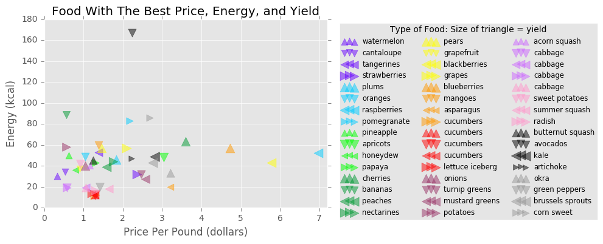

```python
for i in xrange(fresh.shape[0]):
    plt.scatter(fresh["price_per_lb"].iloc[i], fresh["energy"].iloc[i],
                color = myColors[i], alpha = 0.5, label = fresh["food"].iloc[i],
                s = fresh["yield"].iloc[i] * 120, marker = marks[i])

plt.legend(loc='upper center', bbox_to_anchor=(1.5, 1), ncol = 3, prop = fontP, title = "Type of Food: Size of triangle = yield")
plt.title("Food With The Best Price, Energy, and Yield")
plt.ylabel("Energy (kcal)")
plt.xlabel("Price Per Pound (dollars)")
plt.xlim(0, 7.2)
#plt.ylim(0, 22)
plt.show()
```

My second plot is above, and it is the same plot as my first one, but with energy replacing good nutrition. The results of this plot are very similar to my first plot. Avacado does really well and some other foods with a good combination of price, energy, and yield are bananas, potatoes, kale, grapes, and onions.